# study 2

Joseph Outa

2025-1-10

Background: This is the analysis script for Study 2 of the project “Adults hold a causal explanatory framework that connects understanding of other people’s minds, actions and bodies” by Joseph Outa and Shari Liu.

Study 2 had N = 100, with random assignment to two between-subjects conditions: Intervention and Trait Inference, with 15 trials per condition.

Study conducted online with adults on Cloud Research Connect. Study demo: https://liulaboratory-experiments.github.io/mbc/study2

The question: Do subjects flexibly use their latent-cause and direct-cause representations depending on the task? Are subjects in the Intervention condition more likely to select the causal item (based on causal ratings of study 1), and are subjects in the Inference condition more likely to select the similar item (based on results of sorting task of study 1)?

Script description: This script takes as input `study2_data_raw.csv` and `data_freesort_minus_causals.csv`, and plots Supplementary Table 1 in the SI materials, Figure 2 from the main manuscript, and runs statistical models to predict variability in responses from causal and freesort distances.

# 1 Setup

## 1.1 Set options

```r
knitr::opts_chunk$set(echo = TRUE)
library(pacman)
pacman::p_load(tidyverse,
               lme4,
               here,
               patchwork,
               cowplot,
               viridis,
               effects,
               gt,
               webshot2,
               ragg,
               knitr,
               performance)
```

## 1.2 Set variables

```r
# variables
desired_order <- c("see something", "hear something", "choose what to do",
                   "remember something", "think about something", "reach for something",
                   "sit down", "jump up and down", "kick something", "take a walk",
                   "get tired", "become hungry", "feel scared", "experience pain", "get sick")

# paths
## script inputs
base_path <- here("code", "pilot")
data_path <- paste0(base_path, "/data/data-study2/study2_data_raw.csv")
snapshots_input_path <- paste0(base_path,
                               "/analysis/study1-measure/snapshots_study1_pilot_analysis")
freesort_and_causal_distances_df_path <- paste0(snapshots_input_path,
                                                "/freesort_minus_causals.csv")
```

## 1.3 Read data

```r
d <- read.csv(data_path)
```

## 1.4 Demographics

```r
df_demographics <- d %>%
  filter(trial_id == "demographics_survey") %>%
  select("subject_id", "trial_id",
         "feedback", "age", "ethnicity", "gender", "race")

summary(df_demographics$age)
```

```
##    Min. 1st Qu.  Median    Mean 3rd Qu.    Max.
##   18.00   31.00   38.00   39.95   48.25   73.00
```

```r
table(df_demographics$gender)
```

```
##
##     Female       Male Non-binary
##         45         49          5
```

```r
table(df_demographics$ethnicity)
```

```
##
##     Hispanic Non-Hispanic
##            4           94
```

```r
table(df_demographics$race)
```

```
##
##                            Asian           Black/African American
##                               11                               12
##                      Multiracial Native Hawaiian/Pacific Islander
##                                1                                1
##                            White
##                               75
```

## 1.5 Wrangle data frame

```r
 subjects_to_exclude <- d %>%
  filter(condition == "attention_check") %>%
  rowwise() %>%
  mutate(correct_attn_check = case_when(
    grepl(correct_response_attn, selected_choice) ~ "yes",
    TRUE ~ "no"
  )) %>%
  filter(correct_attn_check == "no") %>%
  pull(subject_id) #1 subject: subject 11

dat <- d %>%
  filter(!subject_id %in% subjects_to_exclude) %>% #exclude 1 subject who failed attn check
  filter(condition %in% c("intervention", "similarity")) %>%
  mutate(response = as.factor(response)) %>%
  mutate(condition = as.factor(condition)) %>%
  rowwise() %>%
  mutate(response = case_when(
    grepl(causal_itemA, selected_choice) ~ "causal",
    grepl(similarity_itemA, selected_choice) ~ "similar",
    TRUE ~ "other"
  )) %>%
  mutate(condition = case_when(
    condition == "similarity" ~ "inference",
    TRUE ~ condition
  )) %>%
  ungroup() %>%
  select(subject_id, condition, itemB, causal_itemA, similarity_itemA, response) %>%
  mutate(causal_itemA = factor(causal_itemA, levels = desired_order),
         similarity_itemA = factor(similarity_itemA, levels = desired_order),
         itemB = factor(itemB, levels = desired_order)) %>%
  mutate(domain_itemB = case_when(itemB == "hear something" ~ "mind", #labels for first item of pair
                                 itemB == "choose what to do" ~ "mind",
                                 itemB == "remember something" ~ "mind",
                                 itemB == "think about something" ~ "mind",
                                 itemB == "see something" ~ "mind",
                                 itemB == "reach for something" ~ "action",
                                 itemB == "sit down" ~ "action",
                                 itemB == "jump up and down" ~ "action",
                                 itemB == "kick something" ~ "action",
                                 itemB == "take a walk" ~ "action",
                                 itemB == "get tired" ~ "bio",
                                 itemB == "become hungry" ~ "bio",
                                 itemB == "feel scared"~ "bio",
                                 itemB == "experience pain"~ "bio",
                                 itemB == "get sick"~ "bio"),
         domain_causalitemA = case_when(causal_itemA == "hear something" ~ "mind",
                                 causal_itemA == "choose what to do" ~ "mind",
                                 causal_itemA == "remember something" ~ "mind",
                                 causal_itemA == "think about something" ~ "mind",
                                 causal_itemA == "see something" ~ "mind",
                                 causal_itemA == "reach for something" ~ "action",
                                 causal_itemA == "sit down" ~ "action",
                                 causal_itemA == "jump up and down" ~ "action",
                                 causal_itemA == "kick something" ~ "action",
                                 causal_itemA == "take a walk" ~ "action",
                                 causal_itemA == "get tired" ~ "bio",
                                 causal_itemA == "become hungry" ~ "bio",
                                 causal_itemA == "feel scared"~ "bio",
                                 causal_itemA == "experience pain"~ "bio",
                                 causal_itemA == "get sick"~ "bio"),
          domain_similarityitemA = case_when(similarity_itemA == "hear something" ~ "mind",
                                 similarity_itemA == "choose what to do" ~ "mind",
                                 similarity_itemA == "remember something" ~ "mind",
                                 similarity_itemA == "think about something" ~ "mind",
                                 similarity_itemA == "see something" ~ "mind",
                                 similarity_itemA == "reach for something" ~ "action",
                                 similarity_itemA == "sit down" ~ "action",
                                 similarity_itemA == "jump up and down" ~ "action",
                                 similarity_itemA == "kick something" ~ "action",
                                 similarity_itemA == "take a walk" ~ "action",
                                 similarity_itemA == "get tired" ~ "bio",
                                 similarity_itemA == "become hungry" ~ "bio",
                                 similarity_itemA == "feel scared"~ "bio",
                                 similarity_itemA == "experience pain"~ "bio",
                                 similarity_itemA == "get sick"~ "bio"))
```

# 2 Barplot: condition effect

## 2.1 summarize data

```r
dat_summarized <- dat %>%
  mutate(response = fct_relevel(response, c("similar", "causal"))) %>%
  group_by(condition) %>%
  mutate(total = n()) %>%
  group_by(condition, response) %>%
  summarize(
    count = n(),
    total = first(total),
    mean_proportion = count / total,
    se = sqrt(mean_proportion * (1 - mean_proportion) / total),
    .groups = "drop")
```

## 2.2 plot stacked barplot

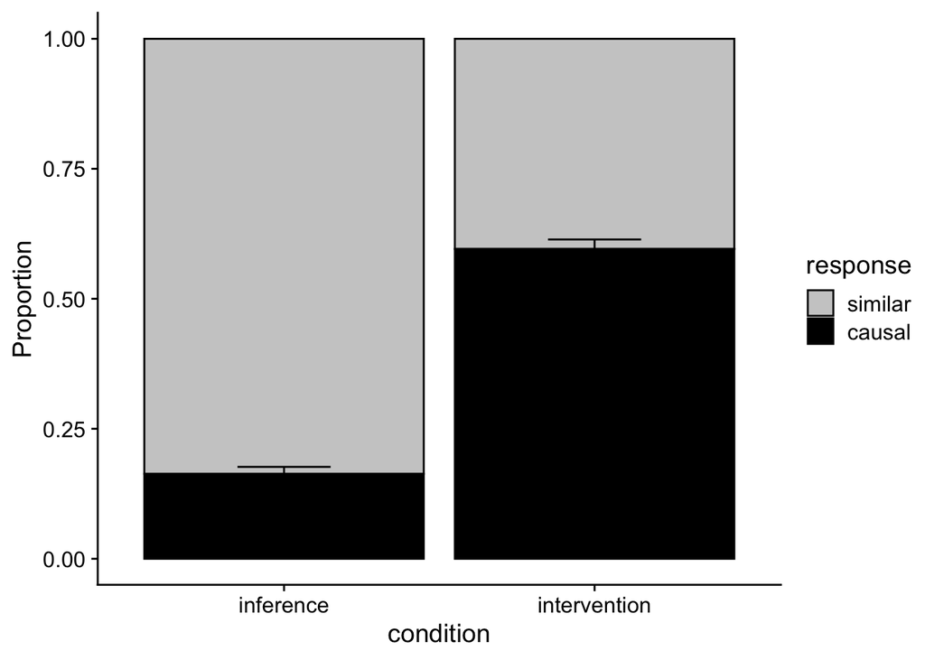

```r
#stacked
(fig_result_summary <- ggplot(dat_summarized, aes(x = condition, y = mean_proportion, fill = response)) +
  geom_bar(stat = "identity", colour = "black") +
  scale_fill_manual(values = c("grey80", "#000000")) +
  geom_errorbar(data = filter(dat_summarized, response == "causal"), aes(ymax = mean_proportion + se,
                                                                         ymin = mean_proportion - se),
                stat = "identity", position = "identity", width = 0.3) +
  theme_cowplot() +
  labs(y = "Proportion"))
```

# 3 Barplot: item level, stacked

## 3.1 summarize df

```r
dat_summarized_by_item <- dat %>%
  mutate(response = fct_relevel(response, c("similar", "causal"))) %>%
  group_by(condition, itemB) %>%
  mutate(total = n()) %>%  #get total responses per condition
  group_by(condition, itemB, response) %>%
  mutate(
    count = n(),  #count responses for each response type
    total = first(total),  #total responses for the condition
    mean_proportion = count / total,  #prop response within condition
    se = sqrt(mean_proportion * (1 - mean_proportion) / total)) %>%
  distinct(condition, itemB, .keep_all = TRUE) %>%
  ungroup()
```

## 3.2 figure for paper

Includes item triads in paper

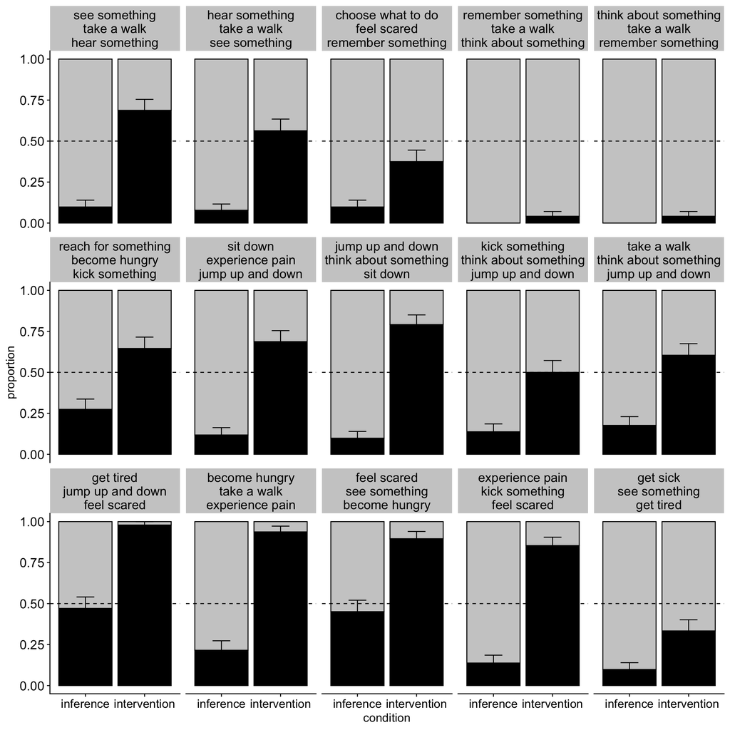

```r
dat_labels <- dat_summarized_by_item %>%
  distinct(itemB, causal_itemA, similarity_itemA) %>%
mutate(facet_label = paste0(
  itemB, "\n",
  "", causal_itemA, "\n",  # black square
  "", similarity_itemA    # white square (or use light gray block)
))


#sort by itemB and extract the ordered facet labels
ordered_facet_labels <- dat_labels %>%
  arrange(itemB) %>%
  pull(facet_label)

#set facet_label as a factor with that order
dat_labels <- dat_labels %>%
  mutate(facet_label = factor(facet_label, levels = ordered_facet_labels))


dat_summarized_by_item_levels <- dat_summarized_by_item %>%
  left_join(dat_labels %>% select(itemB, facet_label), by = "itemB") %>%
  mutate(facet_label = factor(facet_label, levels = ordered_facet_labels))

p_alt2 <- dat_summarized_by_item_levels %>%
  ggplot(aes(x =condition, y = mean_proportion, fill = response)) +
  geom_bar(stat = "identity") +
  geom_bar(stat = "identity", colour = "black") +
  geom_hline(yintercept = 0.5, linetype = "dashed") +
  geom_errorbar(data = filter(dat_summarized_by_item_levels, response == "causal"), aes(ymax = mean_proportion + se,
                                                                         ymin = mean_proportion - se),
                stat = "identity", position = "identity", width = 0.3) +
  scale_fill_manual(values = c("grey80", "#000000")) +
  theme_cowplot() +
  theme(axis.text.x = element_text(size = 14),
        axis.text.y = element_text(size = 15),
        legend.position = "none",
        strip.text = element_text(size = 15)) +
  labs(y = "proportion") +
  facet_wrap(~facet_label, nrow = 3)

p_alt2
```

```r
ggsave(
  filename = "figures/p_study2_item-level_stacked.pdf",
  plot = p_alt2,
  device = "pdf",
  width = 12,
  height = 8,
  units = "in")
```

# 4 Modelling

## 4.1 prepare data frames

```r
d_model <- dat %>%
  mutate(response = as.factor(response)) %>%
  mutate(subject_id = as.factor(subject_id)) %>%
  mutate(responses = ifelse(response == "causal", 1, 0)) %>%
  mutate(condition = as.factor(condition)) %>%
  unite(col = "trial_ID", c(itemB, similarity_itemA, causal_itemA), sep = "_", remove = FALSE)

d_freesort_and_causal_distances <- read_csv(freesort_and_causal_distances_df_path) %>%
  mutate(itemB = factor(itemB, levels = desired_order)) %>%
  mutate(itemA = factor(itemA, levels = desired_order))
intervention_condition <- d_model %>%
  # select(-similarity_itemA) %>% # why - let's study both?
    filter(condition == "intervention") %>%
    left_join(d_freesort_and_causal_distances %>%
                select(itemA, itemB, mean_causal_distance, mean_freesort_distance, freesort_minus_causal) %>%
                rename("causal_itemA" = itemA,
                       "causal_itemA_causal_distance" = mean_causal_distance,
                       "causal_itemA_freesort_distance" = mean_freesort_distance,
                       "causal_itemA_freesort_minus_causal" = freesort_minus_causal),
              by = c("itemB", "causal_itemA")) %>%
    left_join(d_freesort_and_causal_distances %>%
                select(itemA, itemB, mean_causal_distance, mean_freesort_distance, freesort_minus_causal) %>%
                rename("similarity_itemA" = itemA,
                       "similarity_itemA_causal_distance" = mean_causal_distance,
                       "similarity_itemA_freesort_distance" = mean_freesort_distance,
                       "similar_itemA_freesort_minus_causal" = freesort_minus_causal),
              by = c("itemB", "similarity_itemA"))


trait_inference_condition <- d_model %>%
  # select(-causal_itemA) %>%
  filter(condition == "inference") %>%
    left_join(d_freesort_and_causal_distances %>%
                select(itemA, itemB, mean_causal_distance, mean_freesort_distance, freesort_minus_causal) %>%
                rename("causal_itemA" = itemA,
                       "causal_itemA_causal_distance" = mean_causal_distance,
                       "causal_itemA_freesort_distance" = mean_freesort_distance,
                       "causal_itemA_freesort_minus_causal" = freesort_minus_causal),
              by = c("itemB", "causal_itemA")) %>%
    left_join(d_freesort_and_causal_distances %>%
                select(itemA, itemB, mean_causal_distance, mean_freesort_distance, freesort_minus_causal) %>%
                rename("similarity_itemA" = itemA,
                       "similarity_itemA_causal_distance" = mean_causal_distance,
                       "similarity_itemA_freesort_distance" = mean_freesort_distance,
                       "similar_itemA_freesort_minus_causal" = freesort_minus_causal),
              by = c("itemB", "similarity_itemA"))
```

## 4.2 Effect of condition

### 4.2.1 run model

```r
#model
model_effect_of_condition <- glmer(responses ~ condition + (1|subject_id), data = d_model, family = binomial(link = 'logit'))
summary(model_effect_of_condition)
```

```
## Generalized linear mixed model fit by maximum likelihood (Laplace
##   Approximation) [glmerMod]
##  Family: binomial  ( logit )
## Formula: responses ~ condition + (1 | subject_id)
##    Data: d_model
##
##      AIC      BIC   logLik deviance df.resid
##   1649.2   1665.1   -821.6   1643.2     1482
##
## Scaled residuals:
##     Min      1Q  Median      3Q     Max
## -1.5621 -0.5152 -0.3860  0.7693  2.5906
##
## Random effects:
##  Groups     Name        Variance Std.Dev.
##  subject_id (Intercept) 0.2062   0.4541
## Number of obs: 1485, groups:  subject_id, 99
##
## Fixed effects:
##                       Estimate Std. Error z value Pr(>|z|)
## (Intercept)            -1.7089     0.1225  -13.95   <2e-16 ***
## conditionintervention   2.1142     0.1604   13.18   <2e-16 ***
## ---
## Signif. codes:  0 '***' 0.001 '**' 0.01 '*' 0.05 '.' 0.1 ' ' 1
##
## Correlation of Fixed Effects:
##             (Intr)
## cndtnntrvnt -0.773
```

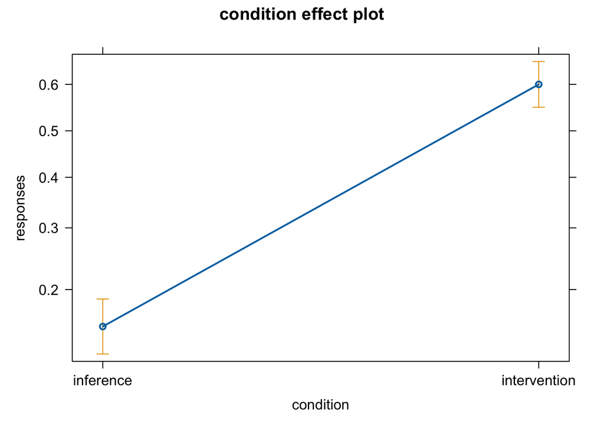

```r
plot(allEffects(model_effect_of_condition))
```

```r
#check_model(model_effect_of_condition) #binned residual issue?

#probabilities
effects_data <- allEffects(model_effect_of_condition)
effects_df <- as.data.frame(effects_data$condition)
effects_df
```

```
##      condition       fit         se     lower     upper
## 1    inference 0.1533101 0.01589780 0.1246717 0.1871208
## 2 intervention 0.5999776 0.02442087 0.5513043 0.6467541
```

### 4.2.2 predictions

model predictions for the probability of specific items, for writeup

```r
#see something
model_with_itemB <- glmer(responses ~ condition * (itemB == "see something") + (1|subject_id),
                          data = d_model, family = binomial(link = 'logit'))
summary(model_with_itemB)
```

```
## Generalized linear mixed model fit by maximum likelihood (Laplace
##   Approximation) [glmerMod]
##  Family: binomial  ( logit )
## Formula: responses ~ condition * (itemB == "see something") + (1 | subject_id)
##    Data: d_model
##
##      AIC      BIC   logLik deviance df.resid
##   1649.3   1675.8   -819.6   1639.3     1480
##
## Scaled residuals:
##     Min      1Q  Median      3Q     Max
## -1.6020 -0.4895 -0.3628  0.7799  3.0157
##
## Random effects:
##  Groups     Name        Variance Std.Dev.
##  subject_id (Intercept) 0.2085   0.4566
## Number of obs: 1485, groups:  subject_id, 99
##
## Fixed effects:
##                                                    Estimate Std. Error z value
## (Intercept)                                         -1.6749     0.1245 -13.453
## conditionintervention                                2.0521     0.1632  12.573
## itemB == "see something"TRUE                        -0.6357     0.4837  -1.314
## conditionintervention:itemB == "see something"TRUE   1.0811     0.5840   1.851
##                                                    Pr(>|z|)
## (Intercept)                                          <2e-16 ***
## conditionintervention                                <2e-16 ***
## itemB == "see something"TRUE                         0.1887
## conditionintervention:itemB == "see something"TRUE   0.0641 .
## ---
## Signif. codes:  0 '***' 0.001 '**' 0.01 '*' 0.05 '.' 0.1 ' ' 1
##
## Correlation of Fixed Effects:
##             (Intr) cndtnn iB=="s
## cndtnntrvnt -0.771
## iB=="s"TRUE -0.166  0.126
## c:B=="s"TRU  0.135 -0.169 -0.828
```

```r
new_data <- data.frame(
  condition = c("inference", "intervention"),
  itemB = "see something",
  subject_id = d_model$subject_id[1]
)

new_data$predicted_response <- predict(model_with_itemB, newdata = new_data, type = "response")
new_data
```

```
##      condition         itemB subject_id predicted_response
## 1    inference see something     subj_1         0.09024844
## 2 intervention see something     subj_1         0.69480303
```

```r
#think about something
model_with_itemB <- glmer(responses ~ condition * (itemB == "think about something") + (1|subject_id),
                          data = d_model, family = binomial(link = 'logit'))
summary(model_with_itemB)
```

```
## Generalized linear mixed model fit by maximum likelihood (Laplace
##   Approximation) [glmerMod]
##  Family: binomial  ( logit )
## Formula: responses ~ condition * (itemB == "think about something") +
##     (1 | subject_id)
##    Data: d_model
##
##      AIC      BIC   logLik deviance df.resid
##   1557.4   1584.0   -773.7   1547.4     1480
##
## Scaled residuals:
##     Min      1Q  Median      3Q     Max
## -1.8018 -0.4686 -0.3567  0.6958  7.1663
##
## Random effects:
##  Groups     Name        Variance Std.Dev.
##  subject_id (Intercept) 0.2648   0.5145
## Number of obs: 1485, groups:  subject_id, 99
##
## Fixed effects:
##                                                            Estimate Std. Error
## (Intercept)                                                 -1.6430     0.1286
## conditionintervention                                        2.2298     0.1719
## itemB == "think about something"TRUE                       -15.8858    25.4108
## conditionintervention:itemB == "think about something"TRUE  12.0574    25.4161
##                                                            z value Pr(>|z|)
## (Intercept)                                                -12.775   <2e-16 ***
## conditionintervention                                       12.973   <2e-16 ***
## itemB == "think about something"TRUE                        -0.625    0.532
## conditionintervention:itemB == "think about something"TRUE   0.474    0.635
## ---
## Signif. codes:  0 '***' 0.001 '**' 0.01 '*' 0.05 '.' 0.1 ' ' 1
##
## Correlation of Fixed Effects:
##             (Intr) cndtnn iB="as
## cndtnntrvnt -0.762
## iB=="as"TRU -0.001  0.000
## c:B=="as"TR  0.001 -0.002 -1.000
```

```r
new_data <- data.frame(
  condition = c("inference", "intervention"),
  itemB = "think about something",
  subject_id = d_model$subject_id[1]
)

new_data$predicted_response <- predict(model_with_itemB, newdata = new_data, type = "response")
new_data
```

```
##      condition                 itemB subject_id predicted_response
## 1    inference think about something     subj_1       2.427814e-08
## 2 intervention think about something     subj_1       3.745277e-02
```

## 4.3 Effect of distances: trait inference condition

### 4.3.1 run model

```r
# Modelling predictors jointly
#model_effect_of_distances_inference <- glmer(responses ~ causal_itemA_freesort_minus_causal + similar_itemA_freesort_minus_causal + (1|subject_id), data = trait_inference_condition, family = binomial(link = "logit")) # TODO figure out failure to converge here --> removed subj_id random effect

model_effect_of_distances_inference <- glm(responses ~ causal_itemA_freesort_minus_causal + similar_itemA_freesort_minus_causal, data = trait_inference_condition, family = binomial(link = "logit"))

summary(model_effect_of_distances_inference)
```

```
##
## Call:
## glm(formula = responses ~ causal_itemA_freesort_minus_causal +
##     similar_itemA_freesort_minus_causal, family = binomial(link = "logit"),
##     data = trait_inference_condition)
##
## Coefficients:
##                                     Estimate Std. Error z value Pr(>|z|)
## (Intercept)                          -6.0083     0.8735  -6.879 6.04e-12 ***
## causal_itemA_freesort_minus_causal   10.6128     2.0622   5.146 2.65e-07 ***
## similar_itemA_freesort_minus_causal  -1.3707     0.6648  -2.062   0.0392 *
## ---
## Signif. codes:  0 '***' 0.001 '**' 0.01 '*' 0.05 '.' 0.1 ' ' 1
##
## (Dispersion parameter for binomial family taken to be 1)
##
##     Null deviance: 681.25  on 764  degrees of freedom
## Residual deviance: 649.08  on 762  degrees of freedom
## AIC: 655.08
##
## Number of Fisher Scoring iterations: 5
```

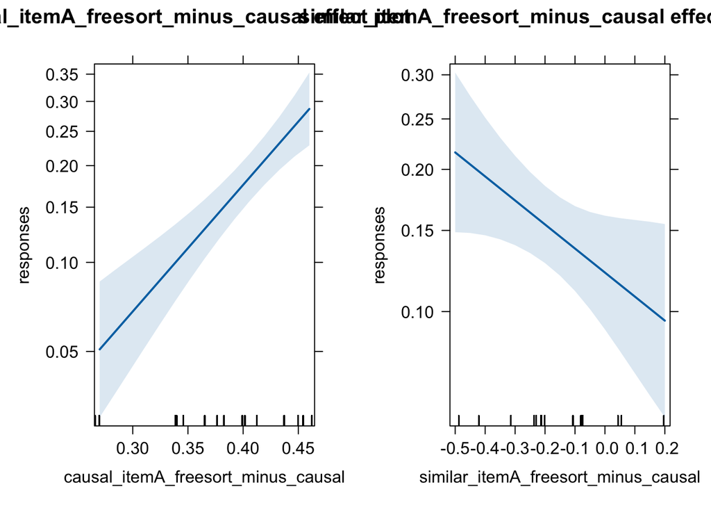

```r
plot(allEffects(model_effect_of_distances_inference))
```

```r
#check_model(model_effect_of_distances_inference)
```

### 4.3.2 figure for paper

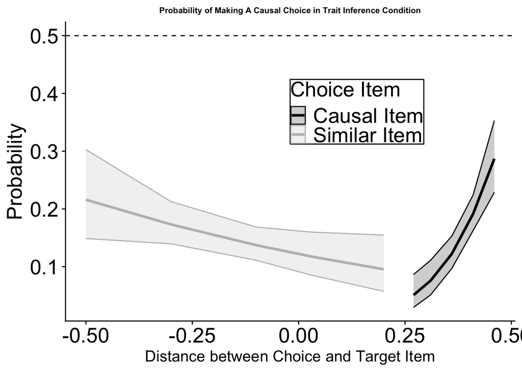

```r
effects_data <- allEffects(model_effect_of_distances_inference)

causal_effect <- as.data.frame(effects_data$`causal_itemA_freesort_minus_causal`)
similar_effect <- as.data.frame(effects_data$`similar_itemA_freesort_minus_causal`)

causal_effect$Predictor <- "Causal Item"
similar_effect$Predictor <- "Similar Item"

colnames(causal_effect)[1] <- "PredictorValue"
colnames(similar_effect)[1] <- "PredictorValue"

combined_effects <- rbind(causal_effect, similar_effect)


base_plot <- ggplot(combined_effects, aes(x = PredictorValue, y = fit, color = Predictor)) +
  geom_line(size = 1.2) +  # Adjust line size for emphasis
  geom_hline(yintercept = .5, linetype = "dashed") +
  geom_ribbon(aes(ymin = lower, ymax = upper, fill = Predictor), alpha = 0.2) +
  scale_color_manual(
    values = c("Causal Item" = "black", "Similar Item" = "grey")
  ) +
  scale_fill_manual(
    values = c("Causal Item" = "black", "Similar Item" = "grey")
  ) +
  labs(
    title = "Probability of Making A Causal Choice in Trait Inference Condition",
    x = "Distance between Choice and Target Item",
    y = "Probability",
    color = "Choice Item",
    fill = "Choice Item"
  ) +
  theme_cowplot() +
  theme(
    plot.title = element_text(hjust = 0.5, size = 8),
    axis.text.x = element_text(size = 20),
    axis.text.y = element_text(size = 20),
    axis.title.y = element_text(size = 20),
    axis.title.x = element_text(size = 15),
    legend.title = element_text(size = 20),
    legend.text = element_text(size = 20),
    legend.position = c(0.5, 0.7) ,  #move legend inside the plot
    legend.background = element_rect(fill = "white", color = "black")  #border around the legend
  )
base_plot
```

## 4.4 Effect of distances: intervention condition

### 4.4.1 run model

```r
#Modelling both predictors
model_effect_of_distances_intervention <- glmer(responses ~ causal_itemA_freesort_minus_causal + similar_itemA_freesort_minus_causal + (1|subject_id), data = intervention_condition, family = binomial(link = "logit"))
summary(model_effect_of_distances_intervention)
```

```
## Generalized linear mixed model fit by maximum likelihood (Laplace
##   Approximation) [glmerMod]
##  Family: binomial  ( logit )
## Formula:
## responses ~ causal_itemA_freesort_minus_causal + similar_itemA_freesort_minus_causal +
##     (1 | subject_id)
##    Data: intervention_condition
##
##      AIC      BIC   logLik deviance df.resid
##    834.8    853.1   -413.4    826.8      716
##
## Scaled residuals:
##     Min      1Q  Median      3Q     Max
## -2.4563 -0.7794  0.4732  0.6041  2.6165
##
## Random effects:
##  Groups     Name        Variance Std.Dev.
##  subject_id (Intercept) 0.1911   0.4371
## Number of obs: 720, groups:  subject_id, 48
##
## Fixed effects:
##                                     Estimate Std. Error z value Pr(>|z|)
## (Intercept)                          -5.3020     0.6110  -8.677  < 2e-16 ***
## causal_itemA_freesort_minus_causal   13.3079     1.5260   8.721  < 2e-16 ***
## similar_itemA_freesort_minus_causal  -4.3697     0.5341  -8.181 2.81e-16 ***
## ---
## Signif. codes:  0 '***' 0.001 '**' 0.01 '*' 0.05 '.' 0.1 ' ' 1
##
## Correlation of Fixed Effects:
##             (Intr) c_A___
## csl_tmA_f__ -0.976
## smlr_tmA___  0.364 -0.245
```

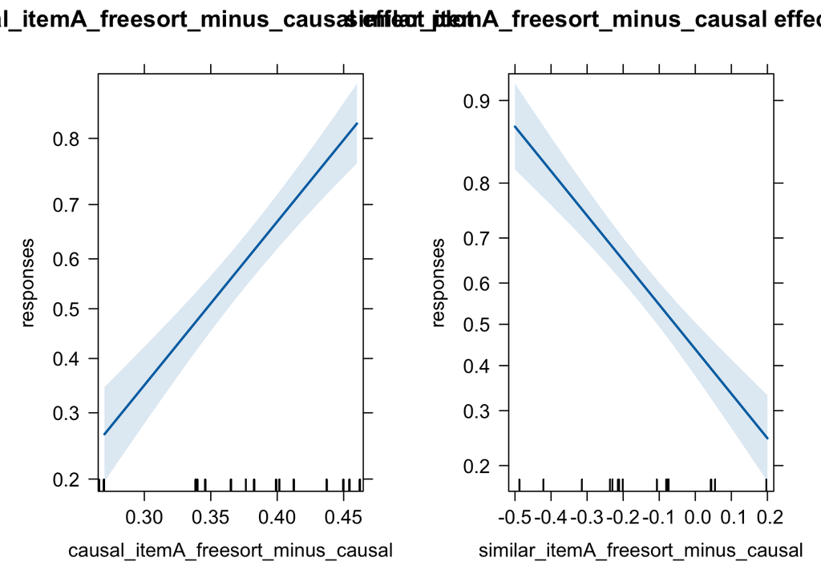

```r
plot(allEffects(model_effect_of_distances_intervention))
```

```r
#check_model(model_effect_of_distances_intervention )

fixed_effects <- fixef(model_effect_of_distances_intervention) #log odds
odds_ratios <- exp(fixed_effects)  #convert log-odds to odds ratios
probabilities <- 1 / (1 + exp(-fixed_effects)) #convert log odds to probability

#nb: fixed effects are intercept and slope. slope is change log odds of outcome for a unit increase in predictor
```

### 4.4.2 figure for paper

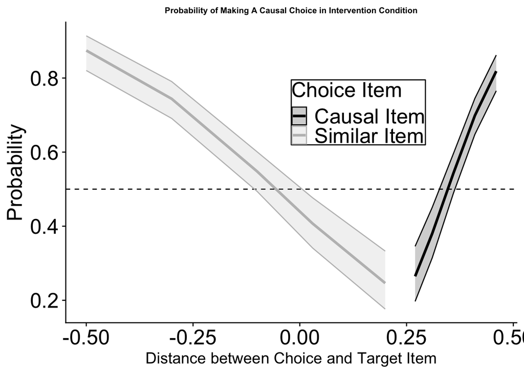

```r
effects_data <- allEffects(model_effect_of_distances_intervention)

causal_effect <- as.data.frame(effects_data$`causal_itemA_freesort_minus_causal`)
similar_effect <- as.data.frame(effects_data$`similar_itemA_freesort_minus_causal`)

causal_effect$Predictor <- "Causal Item"
similar_effect$Predictor <- "Similar Item"

colnames(causal_effect)[1] <- "PredictorValue"
colnames(similar_effect)[1] <- "PredictorValue"

combined_effects <- rbind(causal_effect, similar_effect)

base_plot <- ggplot(combined_effects, aes(x = PredictorValue, y = fit, color = Predictor)) +
  geom_line(size = 1.2) +  # Adjust line size for emphasis
  geom_hline(yintercept = .5, linetype = "dashed") +
  geom_ribbon(aes(ymin = lower, ymax = upper, fill = Predictor), alpha = 0.2) +
  scale_color_manual(
    values = c("Causal Item" = "black", "Similar Item" = "grey")
  ) +
  scale_fill_manual(
    values = c("Causal Item" = "black", "Similar Item" = "grey")
  ) +
  labs(
    title = "Probability of Making A Causal Choice in Intervention Condition",
    x = "Distance between Choice and Target Item",
    y = "Probability",
    color = "Choice Item",
    fill = "Choice Item"
  ) +
  theme_cowplot() +
  theme(
    plot.title = element_text(hjust = 0.5, size = 8),
    axis.text.x = element_text(size = 20),
    axis.text.y = element_text(size = 20),
    axis.title.y = element_text(size = 20),
    axis.title.x = element_text(size = 15),
    legend.title = element_text(size = 20),
    legend.text = element_text(size = 20),
    legend.position = c(0.5, 0.7) ,  #move legend inside the plot
    legend.background = element_rect(fill = "white", color = "black")  #border around the legend

    #plot.margin = margin(20, 20, 50, 20)
  )
base_plot
```